# 04_lda_with_sklearn

## Topic Modeling: Latent Dirichlet Allocation with sklearn

### Imports & Settings

```python
import warnings
warnings.filterwarnings('ignore')
```

```python
%matplotlib inline

from collections import OrderedDict
from pathlib import Path

import numpy as np
import pandas as pd

# Visualization
import matplotlib.pyplot as plt
from matplotlib.ticker import FuncFormatter
import seaborn as sns

import pyLDAvis
from pyLDAvis.sklearn import prepare

from wordcloud import WordCloud
from termcolor import colored

# sklearn for feature extraction & modeling
from sklearn.feature_extraction.text import CountVectorizer, TfidfVectorizer
from sklearn.decomposition import LatentDirichletAllocation
from sklearn.model_selection import train_test_split
import joblib
```

```python
sns.set_style('white')
plt.rcParams['figure.figsize'] = (14.0, 8.7)
```

```python
pyLDAvis.enable_notebook()
```

```python
# change to your data path if necessary
DATA_DIR = Path('../data')
data_path = DATA_DIR / 'bbc'
```

```python
results_path = Path('results')
model_path = Path('results', 'bbc')
if not model_path.exists():
    model_path.mkdir(exist_ok=True, parents=True)
```

## Load BBC data

Using the BBC data as before, we use [sklearn.decomposition.LatentDirichletAllocation](http://scikit-learn.org/stable/modules/generated/sklearn.decomposition.LatentDirichletAllocation.html) to train an LDA model with five topics.

```python
files = sorted(list(data_path.glob('**/*.txt')))
doc_list = []
for i, file in enumerate(files):
    with open(str(file), encoding='latin1') as f:
        topic = file.parts[-2]
        lines = f.readlines()
        heading = lines[0].strip()
        body = ' '.join([l.strip() for l in lines[1:]])
        doc_list.append([topic.capitalize(), heading, body])
```

### Convert to DataFrame

```python
docs = pd.DataFrame(doc_list, columns=['topic', 'heading', 'article'])
docs.info()
```

```
<class 'pandas.core.frame.DataFrame'>
RangeIndex: 2225 entries, 0 to 2224
Data columns (total 3 columns):
 #   Column   Non-Null Count  Dtype
---  ------   --------------  -----
 0   topic    2225 non-null   object
 1   heading  2225 non-null   object
 2   article  2225 non-null   object
dtypes: object(3)
memory usage: 52.3+ KB
```

## Create Train & Test Sets

```python
train_docs, test_docs = train_test_split(docs,
                                         stratify=docs.topic,
                                         test_size=125,
                                         random_state=42)
```

```python
train_docs.shape, test_docs.shape
```

```
((2100, 3), (125, 3))
```

```python
pd.Series(test_docs.topic).value_counts()
```

```
Sport            29
Business         29
Politics         23
Tech             22
Entertainment    22
Name: topic, dtype: int64
```

### Vectorize train & test sets

```python
# experiments with different settings results yields the following hyperparameters (see issue 50)
vectorizer = TfidfVectorizer(max_df=.11,
                             min_df=.026,
                             stop_words='english')

train_dtm = vectorizer.fit_transform(train_docs.article)
words = vectorizer.get_feature_names()
train_dtm
```

```
<2100x1097 sparse matrix of type '<class 'numpy.float64'>'
	with 113356 stored elements in Compressed Sparse Row format>
```

```python
test_dtm = vectorizer.transform(test_docs.article)
test_dtm
```

```
<125x1097 sparse matrix of type '<class 'numpy.float64'>'
	with 6779 stored elements in Compressed Sparse Row format>
```

## LDA with sklearn

```python
n_components = 5
topic_labels = [f'Topic {i}' for i in range(1, n_components+1)]
```

```python
lda_base = LatentDirichletAllocation(n_components=n_components,
                                     n_jobs=-1,
                                     learning_method='batch',
                                     max_iter=10)
lda_base.fit(train_dtm)
```

```
LatentDirichletAllocation(n_components=5, n_jobs=-1)
```

### Persist model

The model tracks the in-sample perplexity during training and stops iterating once this measure stops improving. We can persist and load the result as usual with sklearn objects:

```python
joblib.dump(lda_base, model_path / 'lda_10_iter.pkl')
```

```
['results/bbc/lda_10_iter.pkl']
```

```python
lda_base = joblib.load(model_path / 'lda_10_iter.pkl')
lda_base
```

```
LatentDirichletAllocation(n_components=5, n_jobs=-1)
```

## Explore topics & word distributions

```python
# pseudo counts
topics_count = lda_base.components_
print(topics_count.shape)
topics_count[:5]
```

```
(5, 1097)
```

```
array([[8.31468034, 6.82423569, 9.47292822, ..., 1.62405735, 6.75742624,
        1.59182715],
       [0.21908957, 0.6953881 , 0.81608557, ..., 0.40814018, 2.41744349,
        0.20047286],
       [1.08540207, 4.36071935, 3.83209219, ..., 0.80952393, 6.2400053 ,
        5.32256921],
       [3.56473365, 2.70835622, 1.96359096, ..., 5.37990662, 0.20629507,
        4.65551798],
       [1.35376149, 2.4864043 , 3.4180758 , ..., 2.13436728, 0.28239299,
        4.4297076 ]])
```

```python
topics_prob = topics_count / topics_count.sum(axis=1).reshape(-1, 1)
topics = pd.DataFrame(topics_prob.T,
                      index=words,
                      columns=topic_labels)
topics.head()
```

|  | Topic 1 | Topic 2 | Topic 3 | Topic 4 | Topic 5 |
| --- | --- | --- | --- | --- | --- |
| 100 | 0.001578 | 0.000320 | 0.000615 | 0.001148 | 0.000478 |
| 11 | 0.001295 | 0.001017 | 0.002473 | 0.000872 | 0.000879 |
| 12 | 0.001797 | 0.001194 | 0.002173 | 0.000632 | 0.001208 |
| 13 | 0.000899 | 0.000338 | 0.001881 | 0.000322 | 0.001292 |
| 14 | 0.000846 | 0.001080 | 0.001260 | 0.000731 | 0.001074 |

```python
# all words have positive probability for all topics
topics[topics.gt(0).all(1)].shape[0] == topics.shape[0]
```

```
True
```

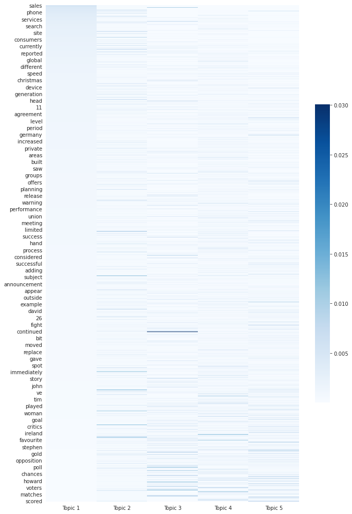

```python
fig, ax = plt.subplots(figsize=(10, 14))
sns.heatmap(topics.sort_values(topic_labels, ascending=False),
            cmap='Blues', ax=ax, cbar_kws={'shrink': .6})
fig.tight_layout()
```

```python
top_words = {}
for topic, words_ in topics.items():
    top_words[topic] = words_.nlargest(10).index.tolist()
pd.DataFrame(top_words)
```

|  | Topic 1 | Topic 2 | Topic 3 | Topic 4 | Topic 5 |
| --- | --- | --- | --- | --- | --- |
| 0 | sales | charges | film | labour | club |
| 1 | technology | drugs | awards | blair | team |
| 2 | growth | russian | award | election | match |
| 3 | mobile | bid | band | party | cup |
| 4 | software | court | star | brown | injury |
| 5 | music | women | music | howard | season |
| 6 | users | trial | album | prime | ireland |
| 7 | digital | offer | actor | eu | final |
| 8 | economy | case | films | secretary | chelsea |
| 9 | computer | russia | singer | lord | wales |

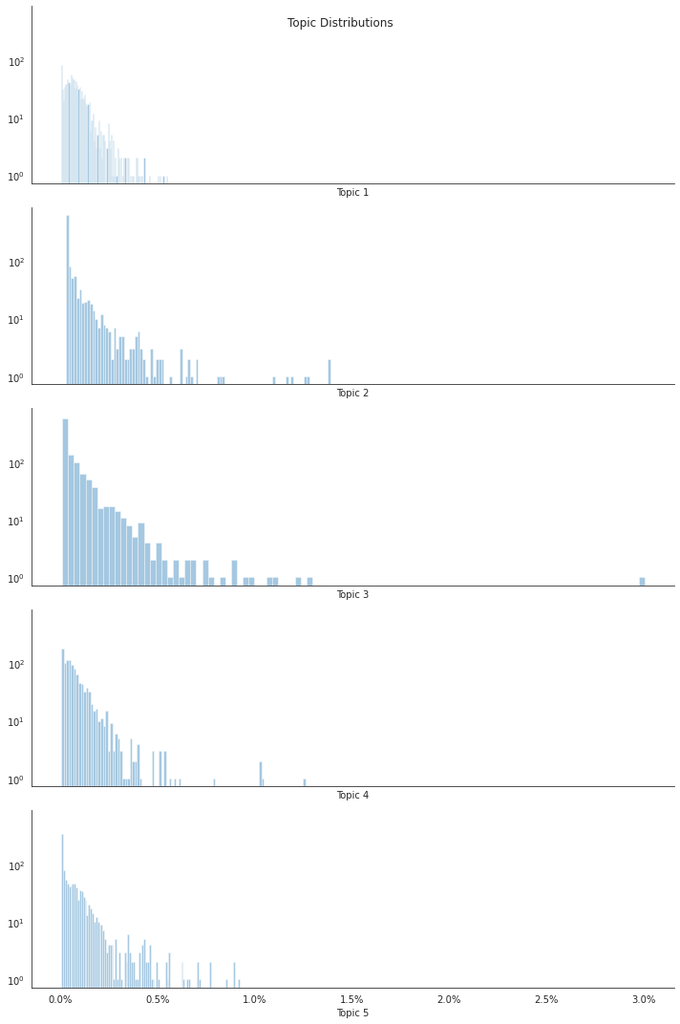

```python
fig, axes = plt.subplots(nrows=5, sharey=True, sharex=True, figsize=(10, 15))
for i, (topic, prob) in enumerate(topics.items()):
    sns.distplot(prob, ax=axes[i], bins=100, kde=False, norm_hist=False)
    axes[i].set_yscale('log')
    axes[i].xaxis.set_major_formatter(FuncFormatter(lambda x, _: '{:.1%}'.format(x)))
fig.suptitle('Topic Distributions')
sns.despine()
fig.tight_layout()
```

## Evaluate Fit on Train Set

```python
train_preds = lda_base.transform(train_dtm)
train_preds.shape
```

```
(2100, 5)
```

```python
train_eval = pd.DataFrame(train_preds, columns=topic_labels, index=train_docs.topic)
train_eval.head()
```

| topic | Topic 1 | Topic 2 | Topic 3 | Topic 4 | Topic 5 |
| --- | --- | --- | --- | --- | --- |
| Sport | 0.029769 | 0.029407 | 0.029715 | 0.029823 | 0.881286 |
| Tech | 0.875581 | 0.030722 | 0.032709 | 0.030722 | 0.030266 |
| Politics | 0.021231 | 0.021085 | 0.021013 | 0.915498 | 0.021173 |
| Sport | 0.041099 | 0.040811 | 0.041030 | 0.041172 | 0.835889 |
| Tech | 0.809909 | 0.029494 | 0.042780 | 0.029660 | 0.088158 |

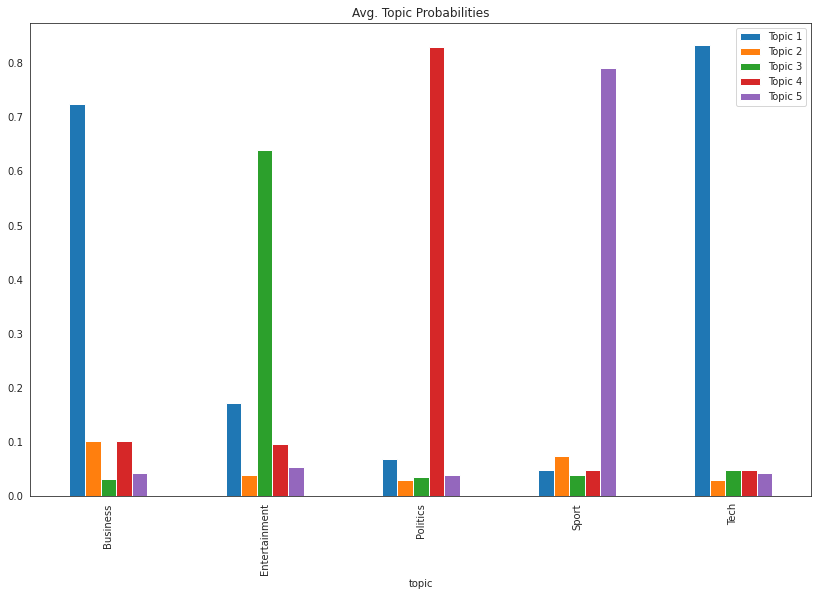

```python
train_eval.groupby(level='topic').mean().plot.bar(title='Avg. Topic Probabilities');
```

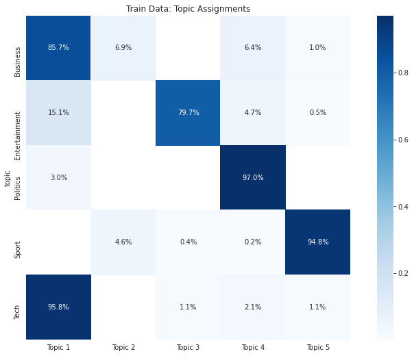

```python
df = train_eval.groupby(level='topic').idxmax(
    axis=1).reset_index(-1, drop=True)
sns.heatmap(df.groupby(level='topic').value_counts(normalize=True)
            .unstack(-1), annot=True, fmt='.1%', cmap='Blues', square=True)
plt.title('Train Data: Topic Assignments');
```

## Evaluate Fit on Test Set

```python
test_preds = lda_base.transform(test_dtm)
test_eval = pd.DataFrame(test_preds, columns=topic_labels, index=test_docs.topic)
test_eval.head()
```

| topic | Topic 1 | Topic 2 | Topic 3 | Topic 4 | Topic 5 |
| --- | --- | --- | --- | --- | --- |
| Politics | 0.025285 | 0.025023 | 0.025241 | 0.897775 | 0.026675 |
| Sport | 0.037109 | 0.215594 | 0.036951 | 0.036369 | 0.673977 |
| Business | 0.842231 | 0.031315 | 0.032697 | 0.031516 | 0.062242 |
| Business | 0.875120 | 0.031362 | 0.031252 | 0.031147 | 0.031118 |
| Tech | 0.880013 | 0.029674 | 0.030008 | 0.030047 | 0.030258 |

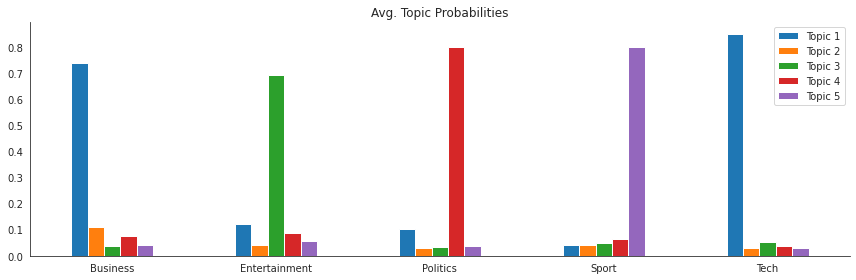

```python
test_eval.groupby(level='topic').mean().plot.bar(title='Avg. Topic Probabilities',
                                                 figsize=(12, 4),
                                                 rot=0)
plt.xlabel('')
sns.despine()
plt.tight_layout()
```

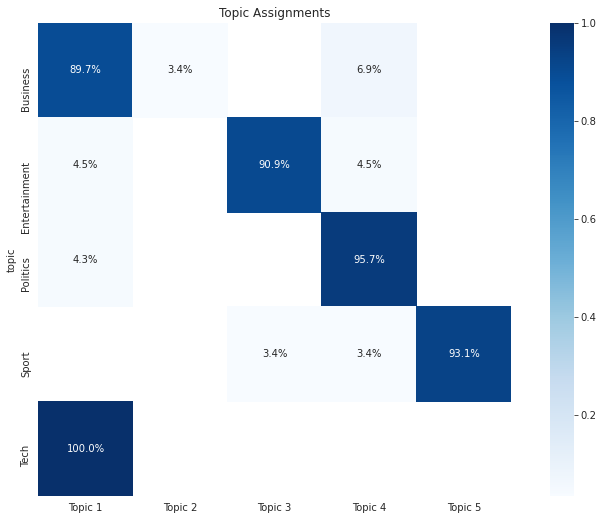

```python
df = test_eval.groupby(level='topic').idxmax(axis=1).reset_index(-1, drop=True)
sns.heatmap(df.groupby(level='topic').value_counts(normalize=True).unstack(-1),
            annot=True, fmt='.1%', cmap='Blues', square=True)
plt.title('Topic Assignments');
```

## Retrain until perplexity no longer decreases

```python
lda_opt = LatentDirichletAllocation(n_components=5,
                                    n_jobs=-1,
                                    max_iter=500,
                                    learning_method='batch',
                                    evaluate_every=5,
                                    verbose=1,
                                    random_state=42)
lda_opt.fit(train_dtm)
```

```
iteration: 1 of max_iter: 500
iteration: 2 of max_iter: 500
iteration: 3 of max_iter: 500
iteration: 4 of max_iter: 500
iteration: 5 of max_iter: 500, perplexity: 1934.2397
iteration: 6 of max_iter: 500
iteration: 7 of max_iter: 500
iteration: 8 of max_iter: 500
iteration: 9 of max_iter: 500
iteration: 10 of max_iter: 500, perplexity: 1874.2381
iteration: 11 of max_iter: 500
iteration: 12 of max_iter: 500
iteration: 13 of max_iter: 500
iteration: 14 of max_iter: 500
iteration: 15 of max_iter: 500, perplexity: 1849.3832
iteration: 16 of max_iter: 500
iteration: 17 of max_iter: 500
iteration: 18 of max_iter: 500
iteration: 19 of max_iter: 500
iteration: 20 of max_iter: 500, perplexity: 1837.3395
iteration: 21 of max_iter: 500
iteration: 22 of max_iter: 500
iteration: 23 of max_iter: 500
iteration: 24 of max_iter: 500
iteration: 25 of max_iter: 500, perplexity: 1831.0049
iteration: 26 of max_iter: 500
iteration: 27 of max_iter: 500
iteration: 28 of max_iter: 500
iteration: 29 of max_iter: 500
iteration: 30 of max_iter: 500, perplexity: 1830.5178
iteration: 31 of max_iter: 500
iteration: 32 of max_iter: 500
iteration: 33 of max_iter: 500
iteration: 34 of max_iter: 500
iteration: 35 of max_iter: 500, perplexity: 1828.5662
iteration: 36 of max_iter: 500
iteration: 37 of max_iter: 500
iteration: 38 of max_iter: 500
iteration: 39 of max_iter: 500
iteration: 40 of max_iter: 500, perplexity: 1828.4966
```

```
LatentDirichletAllocation(evaluate_every=5, max_iter=500, n_components=5,
                          n_jobs=-1, random_state=42, verbose=1)
```

```python
joblib.dump(lda_opt, model_path / 'lda_opt.pkl')
```

```
['results/bbc/lda_opt.pkl']
```

```python
lda_opt = joblib.load(model_path / 'lda_opt.pkl')
```

```python
train_opt_eval = pd.DataFrame(data=lda_opt.transform(train_dtm),
                              columns=topic_labels,
                              index=train_docs.topic)
```

```python
test_opt_eval = pd.DataFrame(data=lda_opt.transform(test_dtm),
                             columns=topic_labels,
                             index=test_docs.topic)
```

## Compare Train & Test Topic Assignments

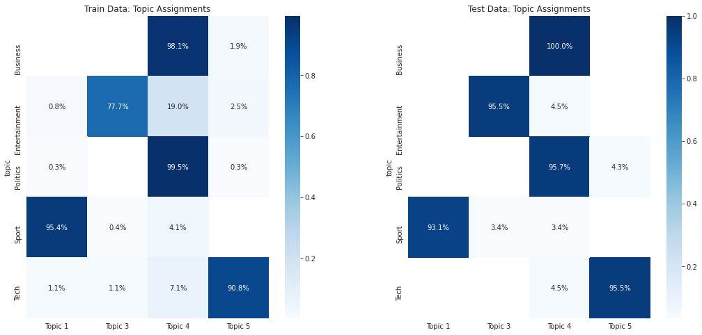

```python
fig, axes = plt.subplots(ncols=2, figsize=(18, 8))
source = ['Train', 'Test']
for i, df in enumerate([train_opt_eval, test_opt_eval]):
    df = df.groupby(level='topic').idxmax(axis=1).reset_index(-1, drop=True)
    sns.heatmap(df.groupby(level='topic').value_counts(normalize=True)
                .unstack(-1), annot=True, fmt='.1%', cmap='Blues', square=True, ax=axes[i])
    axes[i].set_title('{} Data: Topic Assignments'.format(source[i]))
```

## Explore misclassified articles

```python
test_assignments = test_docs.assign(predicted=test_opt_eval.idxmax(axis=1).values)
test_assignments.head()
```

|  | topic | heading | article | predicted |
| --- | --- | --- | --- | --- |
| 1006 | Politics | Kilroy launches 'Veritas' party | Ex-BBC chat show host and East Midlands MEP R... | Topic 4 |
| 1358 | Sport | Radcliffe eyes hard line on drugs | Paula Radcliffe has called for all athletes f... | Topic 1 |
| 71 | Business | S Korean consumers spending again | South Korea looks set to sustain its revival ... | Topic 4 |
| 372 | Business | Quiksilver moves for Rossignol | Shares of Skis Rossignol, the world's largest... | Topic 4 |
| 2151 | Tech | Britons fed up with net service | A survey conducted by PC Pro Magazine has rev... | Topic 5 |

```python
misclassified = test_assignments[(test_assignments.topic == 'Entertainment') & (
    test_assignments.predicted == 'Topic 4')]
misclassified.heading
```

```
677    Campaigners attack MTV 'sleaze'
Name: heading, dtype: object
```

```python
misclassified.article.tolist()
```

```
[' MTV has been criticised for "incessant sleaze" by television indecency campaigners in the US.  The Parents Television Council (PTC), which monitors violence and sex on TV, said the cable music channel offered the "cheapest form" of programming. The group is at the forefront of a vociferous campai…
```

## PyLDAVis

LDAvis helps you interpret LDA results by answer 3 questions:

1. What is the meaning of each topic?
2. How prevalent is each topic?
3. How do topics relate to each other?

Topic visualization facilitates the evaluation of topic quality using human judgment. pyLDAvis is a python port of LDAvis, developed in R and D3.js. We will introduce the key concepts; each LDA implementation notebook contains examples.

pyLDAvis displays the global relationships among topics while also facilitating their semantic evaluation by inspecting the terms most closely associated with each individual topic and, inversely, the topics associated with each term. It also addresses the challenge that terms that are frequent in a corpus tend to dominate the multinomial distribution over words that define a topic. LDAVis introduces the relevance r of term w to topic t to produce a flexible ranking of key terms using a weight parameter 0<=ƛ<=1.

With $\phi_{wt}$ as the model’s probability estimate of observing the term w for topic t, and as the marginal probability of w in the corpus: $$r(w, k | \lambda) = \lambda \log(\phi_{kw}) + (1 − \lambda) \log \frac{\phi_{kw}}{p_w}$$

The first term measures the degree of association of term t with topic w, and the second term measures the lift or saliency, i.e., how much more likely the term is for the topic than in the corpus.

The tool allows the user to interactively change ƛ to adjust the relevance, which updates the ranking of terms. User studies have found that ƛ=0.6 produces the most plausible results.

## Refit using all data

```python
vectorizer = CountVectorizer(max_df=.5,
                             min_df=5,
                             stop_words='english',
                             max_features=2000)
dtm = vectorizer.fit_transform(docs.article)
```

```python
lda_all = LatentDirichletAllocation(n_components=5,
                                    max_iter=500,
                                    learning_method='batch',
                                    evaluate_every=10,
                                    random_state=42,
                                    verbose=1)
lda_all.fit(dtm)
```

```
iteration: 1 of max_iter: 500
iteration: 2 of max_iter: 500
iteration: 3 of max_iter: 500
iteration: 4 of max_iter: 500
iteration: 5 of max_iter: 500
iteration: 6 of max_iter: 500
iteration: 7 of max_iter: 500
iteration: 8 of max_iter: 500
iteration: 9 of max_iter: 500
iteration: 10 of max_iter: 500, perplexity: 1036.6739
iteration: 11 of max_iter: 500
iteration: 12 of max_iter: 500
iteration: 13 of max_iter: 500
iteration: 14 of max_iter: 500
iteration: 15 of max_iter: 500
iteration: 16 of max_iter: 500
iteration: 17 of max_iter: 500
iteration: 18 of max_iter: 500
iteration: 19 of max_iter: 500
iteration: 20 of max_iter: 500, perplexity: 1034.0495
iteration: 21 of max_iter: 500
iteration: 22 of max_iter: 500
iteration: 23 of max_iter: 500
iteration: 24 of max_iter: 500
iteration: 25 of max_iter: 500
iteration: 26 of max_iter: 500
iteration: 27 of max_iter: 500
iteration: 28 of max_iter: 500
iteration: 29 of max_iter: 500
iteration: 30 of max_iter: 500, perplexity: 1033.2341
iteration: 31 of max_iter: 500
iteration: 32 of max_iter: 500
iteration: 33 of max_iter: 500
iteration: 34 of max_iter: 500
iteration: 35 of max_iter: 500
iteration: 36 of max_iter: 500
iteration: 37 of max_iter: 500
iteration: 38 of max_iter: 500
iteration: 39 of max_iter: 500
iteration: 40 of max_iter: 500, perplexity: 1033.1438
```

```
LatentDirichletAllocation(evaluate_every=10, max_iter=500, n_components=5,
                          random_state=42, verbose=1)
```

```python
joblib.dump(lda_all, model_path /'lda_all.pkl')
```

```
['results/bbc/lda_all.pkl']
```

```python
lda_all = joblib.load(model_path / 'lda_all.pkl')
```

#### Lambda

- **$\lambda$ = 0**: how probable is a word to appear in a topic - words are ranked on lift P(word | topic) / P(word)
- **$\lambda$ = 1**: how exclusive is a word to a topic - words are purely ranked on P(word | topic)

The ranking formula is $\lambda * P(\text{word} \vert \text{topic}) + (1 - \lambda) * \text{lift}$

User studies suggest $\lambda = 0.6$ works for most people.

```python
prepare(lda_all, dtm, vectorizer)
```

[interactive chart not shown]

## Topics as WordClouds

```python
topics_prob = lda_all.components_ / lda_all.components_.sum(axis=1).reshape(-1, 1)
topics = pd.DataFrame(topics_prob.T,
                      index=vectorizer.get_feature_names(),
                      columns=topic_labels)
```

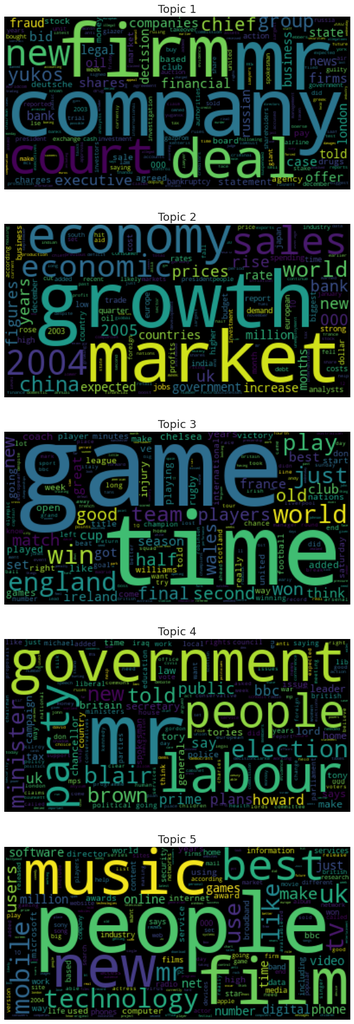

```python
w = WordCloud()
fig, axes = plt.subplots(nrows=5, figsize=(15, 30))
axes = axes.flatten()
for t, (topic, freq) in enumerate(topics.items()):
    w.generate_from_frequencies(freq.to_dict())
    axes[t].imshow(w, interpolation='bilinear')
    axes[t].set_title(topic, fontsize=18)
    axes[t].axis('off')
```

### Visualize topic-word assocations per document

```python
dtm_ = pd.DataFrame(data=lda_all.transform(dtm),
                    columns=topic_labels,
                    index=docs.topic)
```

```python
dtm_.head()
```

| topic | Topic 1 | Topic 2 | Topic 3 | Topic 4 | Topic 5 |
| --- | --- | --- | --- | --- | --- |
| Business | 0.217278 | 0.559808 | 0.001364 | 0.001375 | 0.220175 |
| Business | 0.001366 | 0.929723 | 0.001361 | 0.066198 | 0.001353 |
| Business | 0.992347 | 0.001911 | 0.001914 | 0.001910 | 0.001918 |
| Business | 0.001388 | 0.994458 | 0.001398 | 0.001375 | 0.001381 |
| Business | 0.566180 | 0.425551 | 0.002779 | 0.002776 | 0.002714 |

```python
color_dict = OrderedDict()
color_dict['Topic 1'] = {'color': 'white', 'on_color': 'on_blue'}
color_dict['Topic 2'] = {'color': 'white', 'on_color': 'on_green'}
color_dict['Topic 3'] = {'color': 'white', 'on_color': 'on_red'}
color_dict['Topic 4'] = {'color': 'white', 'on_color': 'on_magenta'}
color_dict['Topic 5'] = {'color': 'blue', 'on_color': 'on_yellow'}
```

```python
dtm_['article'] = docs.article.values
dtm_['heading'] = docs.heading.values
sample = dtm_[dtm_[topic_labels].gt(.05).all(1)]
sample
```

| topic | Topic 1 | Topic 2 | Topic 3 | Topic 4 | Topic 5 | article | heading |
| --- | --- | --- | --- | --- | --- | --- | --- |
| Business | 0.559255 | 0.222441 | 0.064607 | 0.055627 | 0.098070 | One of Japan's best-known businessmen was arr... | Japanese mogul arrested for fraud |
| Business | 0.152645 | 0.519815 | 0.124709 | 0.119207 | 0.083624 | As the Aurora limped back to its dock on 20 J... | Market unfazed by Aurora setback |
| Business | 0.154587 | 0.419691 | 0.252344 | 0.075689 | 0.097689 | Choking traffic jams in Beijing are prompting... | Beijingers fume over parking fees |
| Entertainment | 0.215290 | 0.098103 | 0.150829 | 0.392351 | 0.143427 | Proposals to open a museum dedicated to Jimi ... | Row threatens Hendrix museum plan |
| Entertainment | 0.088833 | 0.179700 | 0.056604 | 0.449340 | 0.225522 | Musicians' groups are to tackle US visa regul... | Musicians to tackle US red tape |
| Politics | 0.222885 | 0.104102 | 0.092383 | 0.357693 | 0.222937 | A group of MPs and peers has called for a tig... | Sport betting rules in spotlight |
| Tech | 0.051874 | 0.173109 | 0.087102 | 0.113349 | 0.574566 | Dublin's hi-tech research laboratory, Media L... | Dublin hi-tech labs to shut down |

```python
colored_text = []
for word in sample.iloc[0, 5].split():
    try:
        topic = topics.loc[word.strip().lower()].idxmax()
        colored_text.append(colored(word, **color_dict[topic]))
    except:
        colored_text.append(word)

print(' '.join([colored(k, **v) for k, v in color_dict.items()]))
print('\n',sample.iloc[0, 6], '\n')
text = ' '.join(colored_text)
print(text)
```

```
Topic 1 Topic 2 Topic 3 Topic 4 Topic 5

 Japanese mogul arrested for fraud

One of Japan's best-known businessmen was arrested on Thursday on charges of falsifying shareholder information and selling shares based on the false data. Yoshiaki Tsutsumi was once ranked as the world's richest man and ran a business spanning hotels, railways, construction and a baseball team. His…
```